# ETC5521 Diving Deeper into Data Exploration: Assignment 1

As per Monash’s integrity rules, these solutions are not to be shared beyond this class.

Author

Prof. Di Cook

Published

July 28, 2025

## 🎯 Goal

The assignment is designed to assess your knowledge of data wrangling and GitHub is at a level to be able to successfully follow the content of this class. The assignment represents 15% of your final grade for ETC5521. This is an **individual** assignment.

## 📌 Guidelines

1. Accept the GitHub Classroom Assignment provided in Moodle using a GitHub Classroom compatible web browser. This should generate a **private** GitHub repository that can be found at https://github.com/etc5521-2025. Your GitHub assignment 1 repo should contain the file `assign01.html`, `README.md`, `assign01-submission.qmd`, `assignment.css`, `etc5521-assignment1.Rproj` and `.gitignore`.
2. Answer each question in the `assign01-submission.qmd` in the repo.
3. For the final submission knit `assign01-submission.qmd` which will contain your answers. Make sure to **provide the link to the script of Generative AI conversation** you employed in arriving at your solution. *Note that marks are allocated for overall grammar and structure of your final report.*
4. Leave all of your files in your GitHub repo for marking. We will check your git commit history. You should have contributions to the repo with consistent commits over time. (*Note: nothing needs to be submitted to Moodle.*)
5. You are expected to **develop your solutions by yourself**, without discussing any details with other class members or other friends or contacts. You can ask for clarifications from the teaching team and we encourage you to attend consultations to get assistance as needed. As a Monash student you are expected to adhere to **[Monash’s academic integrity policy](https://publicpolicydms.monash.edu/Monash/documents/1935748).** and the details on use of Generative AI as detailed on this unit’s Moodle assessment overview. Failure to adhere to this policy may result in a ZERO for this assignment, followed by an academic integrity breach report. The chief examiner reserves the right to question you about any part of your solution.
6. The primary sources for methods needed for this assignment are [R for Data Science (2e)](https://r4ds.hadley.nz) and (Text Mining with R: A Tidy Approach)[https://www.tidytextmining.com).
7. We expect that this assignment takes about 10 hours of time to complete. You should work on this analysis steadily over the time period between release and due date. Spend a couple of hours soon after the assignment is released getting started, and several hours each of the following two weeks to refine your analysis. Your GitHub `commit` history should reflect this working pattern.

Deadlines:

| Due date | Turn in | Points |
| --- | --- | --- |
| 11:45pm Mon Aug 4 | Assignment 1 Repo on GitHub has been created by due date, and commit history shows steady effort on analysis. | 3 |
| 11:45pm Mon Aug 18 | Final solutions available on repo. | 12 |

## Marks

| Part | Points |
| --- | --- |
| GitHub Repo | 3 |
| Q1-Q4 each worth | 3 |
| References and AI | -3 |
| Formatting, spelling, grammar, code and reproducibility | -3 |

Appropriate use of GitHub is an important collaborative analysis skill, and demonstrating this counts towards marks.

Spelling and grammar mistakes and lack of nice formatting, detract from the score because it makes it harder to mark, and harder to read. It is expected that we can reproduce your report, so all code needs to be included, and the code needs to be readable.

Using GAI well is an emerging skill. Inadequate use or over-use without fully processing the responses detracts from a data analysis.

## 🛠️ Exercises

The data to use is available in the [orcas](https://jadeynryan.github.io/orcas/) R package on GitHub. The package can be installed using

`remotes::install_github("jadeynryan/orcas")`

to access the data. The descriptions of the variables can be found [here](https://github.com/rfordatascience/tidytuesday/blob/main/data/2024/2024-10-15/readme.md).

Why are we interested in orca encounters? Whale watching is a major tourism business in many parts of the world. Monitoring the population of whales is important for the sustainability of many businesses and for the health of the planet. Beyond this, orcas are cool! They are intelligent, social, beautiful and one of the top predators in the ocean.

An interesting fact is that orcas routinely helped whalers hunt baleen whales in Two Fold Bay near Eden, Australia, in the 1800s. They would herd the whales into the bay for the whalers. When the whale was killed, the whalers rewarded them with the whales’ tongue and lips. Actually, this is quite gruesome 😳 😬.

**Solution**

```r
library(orcas)
glimpse(cwr_tidy)
```

```
Rows: 775
Columns: 19
$ year               <dbl> 2024, 2024, 2024, 2024, 2024, 2…
$ date               <date> 2024-10-06, 2024-09-16, 2024-0…
$ encounter_sequence <chr> "1", "1", "21", "2", "1", "2", …
$ encounter_number   <dbl> 100, 96, 95, 94, 93, 92, NA, 90…
$ begin_time         <time> 10:48:00, 09:30:00, 02:15:00, …
$ end_time           <time> 12:21:00, 10:11:00, 05:00:00, …
$ duration           <chr> "5580s (~1.55 hours)", "2460s (…
$ vessel             <chr> "Mike 1", "Orcinus", "KCB III, …
$ observers          <chr> "Mark Malleson,Joe Zelwietro", …
$ pods_or_ecotype    <chr> "K, L", "L", "L", "K, L", "J", …
$ ids_encountered    <chr> NA, "L90, L128", "L90 and L128"…
$ location           <chr> "Swiftsure Bank", "Haro Strait"…
$ begin_latitude     <dbl> 49, 48, 49, 49, 49, 49, 48, 49,…
$ begin_longitude    <dbl> -125, -123, -123, -123, -123, -…
$ end_latitude       <dbl> 49, 48, 49, 49, 49, 49, 48, 49,…
$ end_longitude      <dbl> -125, -123, -123, -123, -123, -…
$ encounter_summary  <chr> "After Mark’s encounter with me…
$ nmfs_permit        <chr> "27038/DFO SARA 388", "27038/DF…
$ link               <chr> "https://www.whaleresearch.com/…
```

## Question 1

Summarise the temporal patterns in this data. For example,

- what is the time frame of the data collection?
- are there any seasonal patterns in the measurements?
- what is the usual length of the encounters?

**Solution**

#### Overall time

Examining the year variable to get an overview of the timing of measurements.

```r
yr_smry <- cwr_tidy |> count(year)
yr_smry
```

```
# A tibble: 9 × 2
   year     n
  <dbl> <int>
1  2017   104
2  2018    98
3  2019   107
4  2020    76
5  2021    96
6  2022   101
7  2023    94
8  2024    89
9    NA    10
```

We can see that there are a similar number of encounters every year between 2017 and 2024. We also notice that there are some missing values on `year`, and these observations might need removing for later analysis.

#### Seasonality

Next extract the month and examine if there are any seasonal trends.

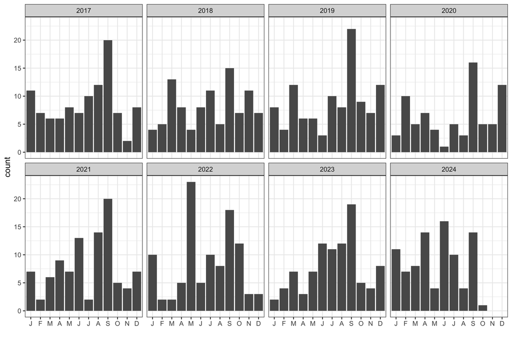

Figure 1

```r
library(lubridate)
cwr_tidy <- cwr_tidy |>
  mutate(month = month(date, label=TRUE))
cwr_tidy |>
  filter(!is.na(month)) |>
  ggplot(aes(x=month)) +
  geom_bar() +
  scale_x_discrete("",
    labels=c("J", "F", "M", "A", "M", "J", "J", "A", "S", "O", "N", "D")) +
  facet_wrap(~year, ncol=4)
```

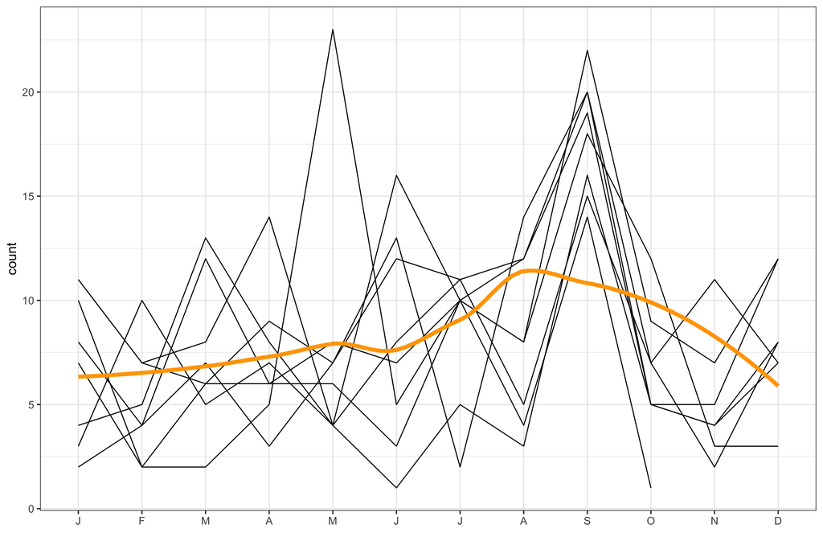

Figure 2

```r
cwr_tidy |>
  filter(!is.na(month)) |>
  group_by(year, month) |>
  count() |>
  ungroup() |>
  ggplot() +
  geom_line(aes(x=month, y=n, group=year),
            linewidth=0.5) +
  geom_smooth(aes(x=as.numeric(month), y=n), se=F,
              colour = "orange", linewidth=2) +
  scale_x_discrete("",
    labels=c("J", "F", "M", "A", "M", "J", "J", "A", "S", "O", "N", "D")) +
  ylab("count")
```

Figure 2 shows that there is some seasonality, that September has uniformly high number of encounters. All other months have a variable number of encounters over the years. In 2022 there was an unusually high number of encounters in May.

#### Duration of encounters

Duration needs to be converted into a numeric variable to make summaries. This requires some text processing using regular expressions, for example converting “5580s (~1.55 hours)” into 5580.

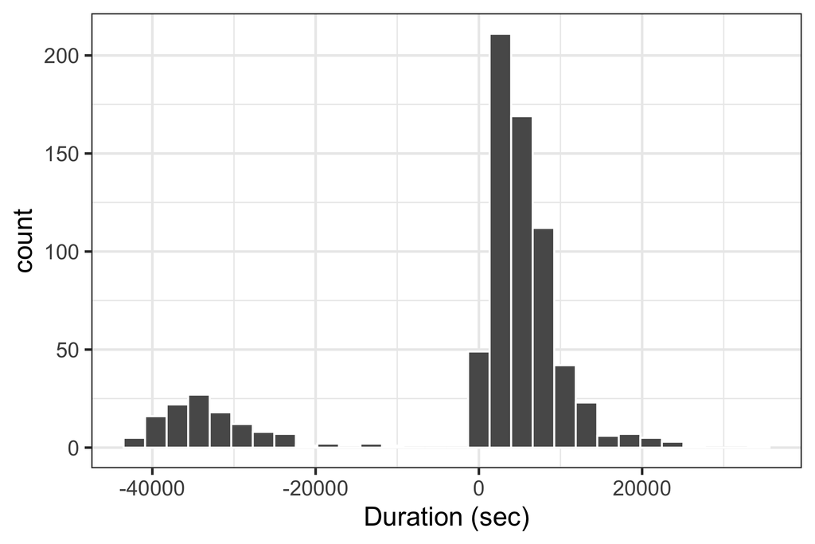

Figure 3

```r
cwr_tidy <- cwr_tidy |>
  mutate(duration_num = str_remove_all(duration, "\\([^)]*\\)")) |>
  mutate(duration_num = as.numeric(str_remove_all(duration_num, "[A-Za-z\\~\\s]")))
ggplot(cwr_tidy, aes(duration_num)) +
  geom_histogram(colour="white") +
  xlab("Duration (sec)")
```

**Marking note**: A complete answer needs to have (1) some summary of the time frame, possibly min and max date, or yearly count as done here, (2) a plot of monthly counts for each year, (3) processing of the duration variable into a numeric variable, (4) noting the negative duration and ideally pointing back to the description in the TidyTuesday website.

## Question 2

Summarise the spatial patterns, for example

- where are these encounters happening?
- are the boats following the whales based on the tracks of the encounters?

**Solution**

#### Spatial location

Plotting the longitude and latitude, particularly overlaid on a map, can help work out where the encounters are happening.

```r
library(leaflet)
cwr_tidy |>
  leaflet() |>
  addTiles() |>
  addCircleMarkers(
    radius=1,
    opacity = 0.5,
    color = "hotpink",
    label = ~date,
    lat = ~begin_latitude, lng = ~begin_longitude)
```

[interactive chart not shown]

These encounters are all in the Puget Sound area of northwest USA, and western Canada.

#### Encounter tracks

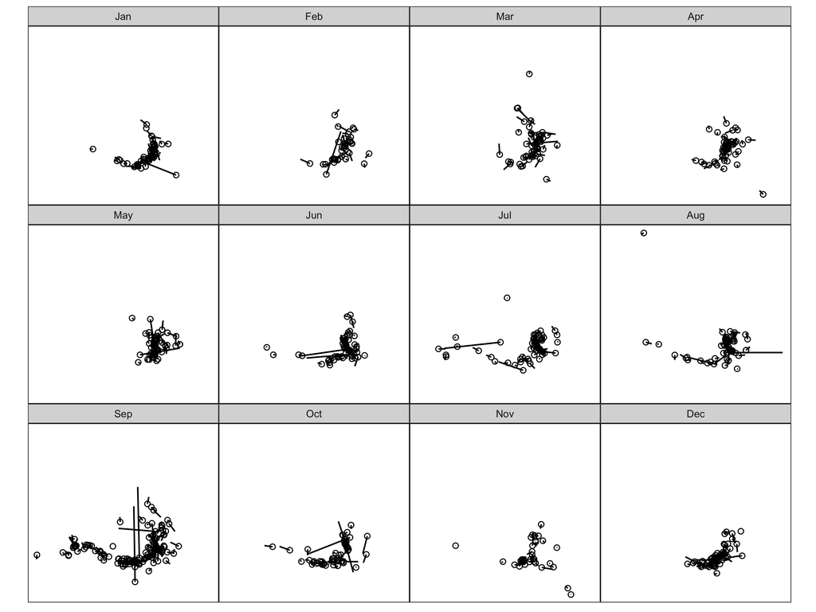

Figure 4: Encounters with segments marking start and end, and circles indicating the start. Most are short. September is when there seems to be more varied locations of encounters.

```r
library(ggthemes)
state <- map_data("state")
washington <- subset(state, region=="washington")
cwr_tidy |>
  filter(!is.na(year)) |>
  ggplot() +
    #geom_polygon(data=washington,
    #             aes(x=long, y=lat, group=group),
    #             fill="khaki3") +
    geom_segment(aes(x=begin_longitude,
                     y=begin_latitude,
                     xend=end_longitude,
                     yend=end_latitude)) +
    geom_point(aes(x=begin_longitude,
                     y=begin_latitude), shape = 1) +
    facet_wrap(~month, ncol=4) +
    #xlim(c(-126, -121)) +
    #ylim(c(47.9, 50.1)) +
    coord_map() +
    theme_map() +
    theme(panel.border = element_rect(colour = "black", fill = NA))
```

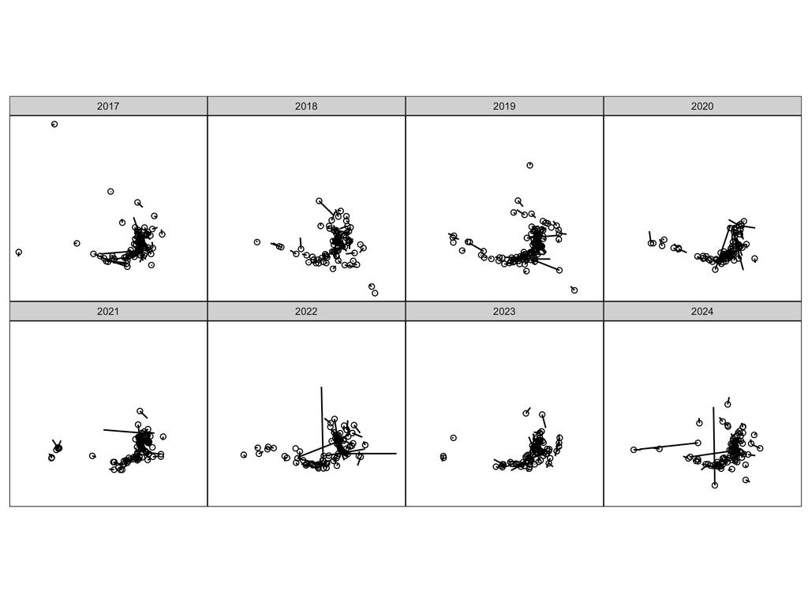

Figure 5: Encounters with segments marking start and end, and circles indicating the start. Most are short. There is little difference between years.

```r
cwr_tidy |>
  filter(!is.na(month)) |>
  ggplot() +
    geom_segment(aes(x=begin_longitude,
                     y=begin_latitude,
                     xend=end_longitude,
                     yend=end_latitude)) +
    geom_point(aes(x=begin_longitude,
                     y=begin_latitude), shape = 1) +
    facet_wrap(~year, ncol=4) +
    coord_map() +
    theme_map() +
    theme(panel.border = element_rect(colour = "black", fill = NA))
```

Most of the encounters are short distance, seen by the small or non-existent lines, as seen in Figure 5.

**Marking note**: A good answer needs (1) all have the spatial locations of all encounters plotted on a map, (2) encounters separated by time, ideally year and month separately, (3) explanation of what is learned.

## Question 3

Summarise the encounters by the vessels and observers. Are they the same whales that are frequently seen?

- Are there some especially frequent observers or active vessels?
- Are the long encounters made by special vessels?
- Do some vessels make multiple encounters?

**Solution**

```r
vessel_cnt <- cwr_tidy |>
  count(vessel, sort=TRUE)
vessel_cnt |>
  filter(n > 9)
```

```
# A tibble: 5 × 2
  vessel           n
  <chr>        <int>
1 Orcinus        312
2 Mike 1         300
3 KCB III         43
4 Morning Star    33
5 Chimo           22
```

There are two especially active vessels Orcinus and Mike 1.

```r
cwr_tidy |>
  filter(duration_num < 0) |>
  count(vessel, sort=TRUE) |>
  filter(!is.na(vessel))
```

```
# A tibble: 5 × 2
  vessel                                               n
  <chr>                                            <int>
1 Mike 1                                              52
2 Orcinus                                             52
3 KCB III                                             15
4 KCB IIIRachel John, Arlene Vargas, Charli Grimes     1
5 Orca                                                 1
```

It is the same two vessels also are the ones that made long (negative) encounters.

```r
cwr_tidy |>
  count(observers, sort=TRUE)
```

```
# A tibble: 251 × 2
   observers                                n
   <chr>                                <int>
 1 Dave Ellifrit                           96
 2 Mark Malleson                           76
 3 Mark Malleson, Joe Zelwietro            40
 4 Mark Malleson,Joe Zelwietro             24
 5 Dave Ellifrit, Katie Jones              22
 6 Ken Balcomb                             22
 7 Melisa Pinnow, Jane Cogan, Tom Cogan    22
 8 Mark Malleson,Brendon Bissonnette       18
 9 Dave Ellifrit, Michael Weiss            12
10 Mark Malleson, Hanna Magnusson          12
# ℹ 241 more rows
```

Some problems remain in the data in that some vessel names and observer names are together in the strings. To further clean the data the strings need to be split, and names recounted. Then we might be able to address whether the people are always associated with the same boats.

```r
vessel_tidy <- cwr_tidy |>
  separate(vessel, c("vessel1", "vessel2", "vessel3", "vessel4"), sep = ",", fill = "right") |>
  pivot_longer(vessel1:vessel4,
               names_to="var", values_to="vessel") |>
  filter(!is.na(vessel))
vessel_cnt <- vessel_tidy |>
  count(vessel, sort=TRUE)
vessel_cnt |>
  filter(n > 9)
```

```
# A tibble: 5 × 2
  vessel           n
  <chr>        <int>
1 Orcinus        314
2 Mike 1         305
3 KCB III         44
4 Morning Star    35
5 Chimo           22
```

```r
observers_tidy <- cwr_tidy |>
  separate(observers, c("observers1", "observers2", "observers3", "observers4", "observers5", "observers6", "observers7", "observers8", "observers9", "observers10", "observers11", "observers12"), sep = ",", fill = "right") |>
  pivot_longer(observers1:observers12,
               names_to="var", values_to="observers") |>
  filter(!is.na(observers)) |>
  filter(observers != "") |>
  mutate(observers = str_trim(observers, "both"))
observers_cnt <- observers_tidy |>
  count(observers, sort=TRUE)
observers_cnt |>
  filter(n > 20)
```

```
# A tibble: 15 × 2
   observers               n
   <chr>               <int>
 1 Mark Malleson         297
 2 Dave Ellifrit         283
 3 Michael Weiss         145
 4 Joe Zelwietro          99
 5 Rachel John            52
 6 Katie Jones            44
 7 Melisa Pinnow          44
 8 Ken Balcomb            40
 9 Federica Spina         34
10 Tom Cogan              31
11 Jane Cogan             30
12 Charli Grimes          28
13 Darren Croft           27
14 Alyssa Kelley          26
15 Brendon Bissonnette    26
```

The top observers are still the same. This hasn’t perfectly cleaned the strings because there remain some where multiple observers are noted with “and”. It would take more processing to fix this, at least to account for two observers with the same surname.

```r
cwr_tidy |>
  mutate(pods_or_ecotype = str_replace_all(pods_or_ecotype, " and ", ",")) |>
  separate(pods_or_ecotype, c("pods1", "pods2", "pods3", "pods4", "pods5", "pods6", "pods7", "pods8", "pods9", "pods10", "pods11", "pods12"), sep = ",", fill = "right") |>
  pivot_longer(pods1:pods12,
               names_to="var", values_to="pods") |>
  filter(!is.na(pods)) |>
  filter(pods != "") |>
  mutate(pods = str_remove_all(pods, " Pod")) |>
  mutate(pods = str_remove_all(pods, " pod")) |>
  mutate(pods = str_trim(pods, "both")) |>
  count(pods, sort=TRUE) |>
  filter(n > 9)
```

```
# A tibble: 8 × 2
  pods                     n
  <chr>                <int>
1 Transients             341
2 J                      215
3 L                       94
4 K                       79
5 Bigg's killer whales    61
6 L87                     16
7 Bigg's Transients       12
8 Ls                      11
```

The same pre-processing needs to be done for the pods. This provides an incomplete processing because there are still some pods with names that might be the same pod, like “L” and “Ls” but these numbers are small. So ignoring these last changes, primarily the pods are listed as “Transients”, and there are just three named pods “J”, “K” and “L”.

**Marking note**: The answer needs to have (1) some counts of these different variables, (2) text wrangling to split strings for better counting, (3) paragraphs describing results.

## Question 4

Each encounter has a text description. Summarise the common words used for the encounters.

**Solution**

Text processing of the paragraphs for each encounter needs to be conducted. This will break up the descriptions into a bag of words. The summary needs to focus on frequency of words used. You can choose to make a bar chart of most frequent words, or the wordcloud. If using a wordcloud, it helps to manage the size of words in order to lay them out better.

Either way, it is important to add more words to the stop words set to remove irrelevant words like observers names.

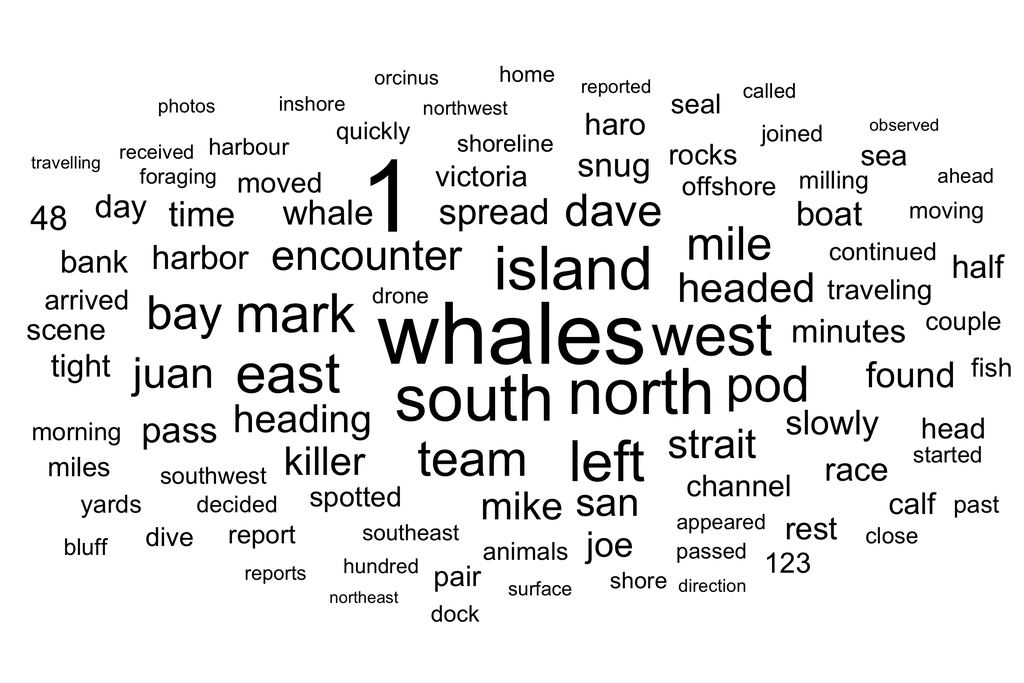

Figure 6: Word cloud of top 100 words.

```r
library(tidytext)
library(ggwordcloud)
cwr_text <- cwr_tidy |>
  unnest_tokens(word, encounter_summary) |>
  select(word) |>
  anti_join(stop_words)

cwr_text_top <- cwr_text |>
  filter(!is.na(word)) |>
  count(word, sort=TRUE) |>
  slice_head(n=100)
cwr_text_top |>
  ggplot() +
  geom_text_wordcloud_area(aes(label = word, size=n)) +
  scale_size_area(max_size = 30) +
  theme_minimal()
```

**Marking note**: This question is primarily looking for the ability to process the text, to make a frequency plot or wordcloud. Good answers will have a top X list, some irrelevant words removed, and also a summary like the paragraph above.

## Resources

In this part, you should cite major resources used, including R packages, and actively discuss how generative AI helped with your answers to the assignment questions, and where or how it was mistaken or misleading.

You need to provide links to the full script of your conversations generative AI tools. You should not use a paid service, as the freely available systems will sufficiently helpful.

For example, the `citation()` function in R can give R package details:

Wickham H, Averick M, Bryan J, Chang W, McGowan LD, François R, Grolemund G, Hayes A, Henry L, Hester J, Kuhn M, Pedersen TL, Miller E, Bache SM, Müller K, Ooms J, Robinson D, Seidel DP, Spinu V, Takahashi K, Vaughan D, Wilke C, Woo K, Yutani H (2019). “Welcome to the tidyverse.” *Journal of Open Source Software*, *4*(43), 1686. [doi:10.21105/joss.01686](https://doi.org/10.21105/joss.01686)..

The links to my use of ChatGPT for help on this assignment are:

- https://chatgpt.com/share/68857a22-debc-8001-bfcc-10552befba4c helped to construct the regex to process the duration variable.

## Rubric

To help you complete in your report, below is a rubric to guide you to what we are expecting:

| content | Excellent (HD) | Very good (D) | Good (C) | Satisfactory (P) | Unsatisfactory (F) |
| --- | --- | --- | --- | --- | --- |
| Q1-4 | Plots and summaries are comprehensive and concise. Summaries are designed well and polished. Text is used to summarise the tables and plots. Anything interesting or problematic with the data is discus… | Plots and summaries are complete and concise. Summaries are appropriate. Text is addd to summarise the tables and plots. Interesting or problematic aspects of the data are reported. | Plots and summaries mostly answer questions raised by the initial expectations, are provide good answers and reasoning. | Plots and summaries are not complete or there are too many summaries provided. Summaries are mostly appropriate. Text is addd to summarise the tables and plots. | Plots and tables are not well matched to the needed, and text explanations are not provided. Plots are not readable. |
| Repo | Actively commiting during entire assignment period, with informative commit messages, done after each small change to the work. Commiting changes during most of assignment period, with clear evolution… |  | Repo not accepted in time, and less than 11 commits (2) | Repo not accepted in time, and less than 5 commits (1) | Repo not accepted in time, and a single commit (0) |
| GAI | GAI used effectively, deeply, and explained, script linked to report (0 deduction) |  | GAI used but not explained well or inadequate and script linked to report (-0.5) | Shallow use of GAI, script linked to report (-1) | Clearly used but no script linked to report (-3) |
| Reproducibility | No changes needed for report to reproduce exactly as provided. Code is nicely formatted, commented and readable using appropriate tidyverse standards. (0 deduction) | Single change needed for report to reproduce exactly as provided. Code is nicely formatted, commented and readable using appropriate tidyverse standards. (0 deduction) | Just a few changes needed for report to reproduce exactly as provided. Code is formatted, commented and readable using appropriate tidyverse standards. (-0.5) | Multiple changes needed for report to reproduce exactly as provided. Code is readable. (-1) | Cannot easily make changes for report to reproduce at all. Code is not readable. (-2) |
| Spelling/Grammar | Writing style is exceptional, scholarly and succinct that is free from spelling, grammar and punctuation errors. (0 deduction) | Writing style is scholarly, free from spelling, grammar and punctuation errors. (0 deduction) | Writing style is scholarly, but wordy and inconcise. Free from spelling, grammar and punctuation errors. (-0.5) | Writing is scholarly and wordy. Contains some grammatical, punctuation and spelling errors. (-1) | Writing is unscholarly. Many grammatical, punctuation and spelling errors. (-2) |
| References | The appropriate referencing style has been used consistently, with no errors. Includes citations for software used, and data sources. (0 deduction) | The appropriate referencing style has been used consistently, with very few errors, and includes software used, and data sources. (0 deduction) | The appropriate referencing style has been used consistently, and only a few citations missing. (-0.5) | The appropriate referencing style has been used much of the time, missing some major sources that were clearly used. (-1) | Material used from external sources without citation. (-2) |